# Report on the Practical Machine Learning Assignment

Ian T.

Friday, 14th August, 2015

## Introduction

This report documents an analysis conducted for the Coursera Practical Machine Learning course assignment.

The aim of the analysis was to develop an algorithm to classify dumb bell lifts into 5 groups. The first category (A) comprises correct lifts and the other 4 categories (B–E) comprise lifts done with 4 distinct common errors.

Vellosso et al. (2013) describe the study and further information on it is available here http://groupware.les.inf.puc-rio.br/har (see the section on the *Weight Lifting Exercise Dataset*)

## Preprocessing of the data

The data comprise two files: a large training dataset and 20 observations for which the classification variable has been held back that are used to assess the final classificatory model. Both files were downloaded and read into R.

The training data for this project are available here: https://d396qusza40orc.cloudfront.net/predmachlearn/pml-training.csv

The test data are available here: https://d396qusza40orc.cloudfront.net/predmachlearn/pml-testing.csv

```r
# Housekeeping
setwd("D:/Ian/git/datasciencecoursera/MachineLearning")
library(caret); library(ggplot2);
library(reshape2); library(randomForest)

# One-time download of files and import them into R
if (!file.exists("pml_training.RDS")) {
    myURL <- "https://d396qusza40orc.cloudfront.net/predmachlearn/"
    dname <- "pml_testing.csv"
    download.file(paste0(myURL, "pml-testing.csv"), dname)
    pml_testing <- read.csv(dname)
    saveRDS(pml_testing, file = "pml_testing.RDS")
    dname <- "pml_training.csv"
    download.file(paste0(myURL, "pml-training.csv"), dname)
    pml_training <- read.csv(dname)
    saveRDS(pml_training, file = "pml_training.RDS")
}
```

The original data include a number of identifiers that are of no use for making predictions for other individuals and numerous summary variables describing each lift as a whole. As this analysis was conducted at the level of the 19,622 individual sets of measurements, the identifiers and summary variables were all discarded.

In order to assess the out-of-sample accuracy of the algorithms, the large training dataset was randomly split 70/30, stratifying on the outcome classification. The two resulting datasets were used as training and test datasets respectively for the purposes of this analysis.

There were no missing values in the sensor data and no variables with near zero variance. However, 6 extreme outlying measurements had been recorded in one of the observations. Replacement values for these measurements were imputed using the k nearest neighbours algorithm.

All the sensor measurements were centred and standardized.

```r
# One-time set up of my training and test files and 20 assessment cases
if (!file.exists("pml_mytrain.RDS")) {
    if (!exists("pml_training")) pml_training <-
            readRDS("pml_training.RDS")
    # Drop everything except raw measures and classe outcome
    work0 <- pml_training[, c(8:11, 37:49, 60:68, 84:86, 102,
                               113:124, 140, 151:160)]
    print(dim(pml_training)); print(dim(work0))
    remove(pml_training)
    # Check whether there are any missing values left
    print(sum(apply(work0, 2, function(x) sum(is.na(x)))))

    # Set aside 30% of measures for validation
    set.seed(37374)
    inTrain <- createDataPartition(work0$classe, p = 0.7, list = FALSE)
    work1 <- work0[inTrain,]

    # Preprocessing: standardize all the predictors
    preObj1 <- preProcess(work1[, -53], method = c("center", "scale"))
    work2 <- predict(preObj1, work1[ , -53])

    # Preprocessing: set extreme outliers to missing and impute them
    work2 <- apply(work2, 2, function(x) {x[x > 12] <- NA; x})
    work2 <- apply(work2, 2, function(x) {x[x < -12] <- NA; x})
    preObj2 <- preProcess(work2, method="knnImpute")
    work3 <- predict(preObj2, work2)
    work2[which(is.na(work2))] <- work3[which(is.na(work2))]
    pml_mytrain <- data.frame(work2, work1$classe)
    colnames(pml_mytrain)[53] <- "classe"
    saveRDS(pml_mytrain, file = "pml_mytrain.RDS")

    # Repeat preprocessing on the test data
    work1 <- work0[-inTrain,]
    work2 <- predict(preObj1, work1[ , -53])
    work2 <- apply(work2, 2, function(x) {x[x > 12] <- NA; x})
    work2 <- apply(work2, 2, function(x) {x[x < -12] <- NA; x})
    work3 <- predict(preObj2, work2)
    work2[which(is.na(work2))] <- work3[which(is.na(work2))]
    pml_mytest <- data.frame(work2, work1$classe)
    colnames(pml_mytest)[53] <- "classe"
    saveRDS(pml_mytest, file = "pml_mytest.RDS")

    # And now on the 20 cases for the assessment
    if (!exists("pml_testing")) pml_testing <- readRDS("pml_testing.RDS")
    work1 <- pml_testing[, c(8:11, 37:49, 60:68, 84:86, 102,
                           113:124, 140, 151:160)]
    work2 <- predict(preObj1, work1[ , -53])
    work2 <- apply(work2, 2, function(x) {x[x > 12] <- NA; x})
    work2 <- apply(work2, 2, function(x) {x[x < -12] <- NA; x})
    work3 <- predict(preObj2, work2)
    work2[which(is.na(work2))] <- work3[which(is.na(work2))]
    pml_final <- data.frame(work2)
    saveRDS(pml_final, file = "pml_final.RDS")

    print(dim(pml_mytrain)); print(dim(pml_mytest)); print(dim(pml_final))

    # Tidy up environment
    remove(work0, work1, work2, work3, inTrain)
} else {
    pml_mytrain <- readRDS("pml_mytrain.RDS")
}
```

# Exploratory data analysis

Figure 1 shows the distributions of the 52 sensor measurements. There seems no strong case for transforming either the whole lot or a subset of them to reduce their skew.

Figure 2 looks at the relationship between the measures and the 5 different classes of dumb bell lifts. None of the measures individually are strong predictors of class of dumb bell lift.

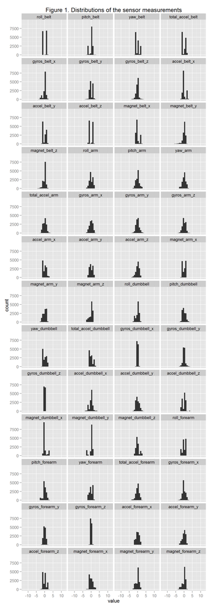

```r
# Examine variable distributions and association with classe
ggplot(melt(pml_mytrain[, -53])) + aes(x = value) +
    facet_wrap(~variable, ncol = 4) + geom_histogram() +
    ggtitle("Figure 1. Distributions of the sensor measurements")
```

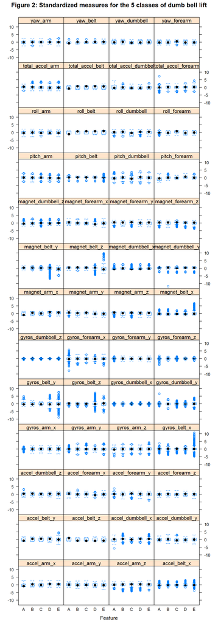

```r
featurePlot(x = pml_mytrain[, -53], y = pml_mytrain$classe,
    plot = "box", layout = (c(4,13)),
    main = ("Figure 2: Standardized measures for the 5 classes of dumb bell lift"))
```

## Tuning of candidate algorithms

Before deciding what algorithm to adopt, I assessed the performance of the following five models:

- a linear discriminant analysis (method: *lda*)
- a naive Bayes model (method: *nb*)
- a straightforward decision tree (method: *rpart*)
- a boosted decision tree (method: *gbm*)
- a random forest (method: *rf*).

The discriminant analysis, naive Bayes model and two decision trees were all tuned using cross-validation with 3 repeats of 10 folds (e.g. Figure 4). The random forest was tuned using its internal estimates of OOB accuracy.

```r
# Fit classification tree
if (!file.exists("treeFit.RDS")) {
    set.seed(8569)
    tc <- trainControl(method = "repeatedcv", repeats = 3)
    treeFit <- train(classe ~ ., method = "rpart", data = pml_mytrain,
                     tuneLength = 10, trControl = tc)
    saveRDS(treeFit, file = "treeFit.RDS")
} else {
    treeFit <- readRDS("treeFit.RDS")
}
t_classes <- predict(treeFit)
treeFit$results
```

```
##            cp  Accuracy      Kappa AccuracySD    KappaSD
## 1  0.01200285 0.6930687 0.61213319 0.02248926 0.02796872
## 2  0.01800427 0.6785368 0.59377704 0.01749699 0.02166106
## 3  0.01942834 0.6594134 0.57028986 0.02266870 0.02763649
## 4  0.01963178 0.6467254 0.55460905 0.02334412 0.02854010
## 5  0.02481945 0.5602331 0.43185385 0.03363972 0.05050486
## 6  0.02502289 0.5583152 0.42941578 0.03125175 0.04724178
## 7  0.03092259 0.5321111 0.39216849 0.02501523 0.03789636
## 8  0.03275353 0.5170686 0.37206092 0.03111165 0.04624590
## 9  0.06031940 0.4290824 0.23078622 0.06122354 0.10382650
## 10 0.11626488 0.3232442 0.05922494 0.03965451 0.06039009
```

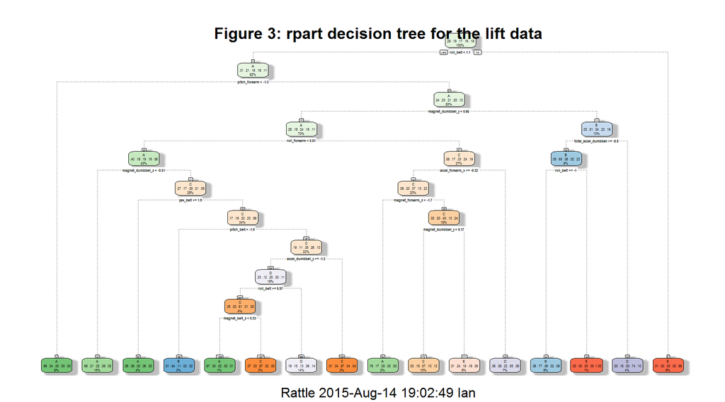

```r
library(rattle); library(rpart.plot)
fancyRpartPlot(treeFit$finalModel,
           main = "Figure 3: rpart decision tree for the lift data")
```

```r
# Fit linear discriminant analysis
if (!file.exists("ldaFit.RDS")) {
    set.seed(8569)
    tc <- trainControl(method = "repeatedcv", repeats = 3)
    ldaFit <- train(classe ~ ., method = "lda", data = pml_mytrain,
                    trControl = tc)
    saveRDS(ldaFit, file = "ldaFit.RDS")
} else {
    ldaFit <- readRDS("ldaFit.RDS")
}
l_classes <- predict(ldaFit)

# Fit gradient boosted tree
if (!file.exists("booFit.RDS")) {
    set.seed(8569)
    tc <- trainControl(method = "repeatedcv", repeats = 3)
    gbmGrid <-  expand.grid(interaction.depth = c(3, 7, 12),
                            n.trees = c(150, 250, 400),
                            shrinkage = 0.1, n.minobsinnode = 5)
    booFit <- train(classe ~ ., method="gbm", data=pml_mytrain,
               tuneGrid = gbmGrid, trControl = tc, verbose = TRUE)
    saveRDS(booFit, file = "booFit.RDS")
} else {
    booFit <- readRDS("booFit.RDS")
}
b_classes <- predict(booFit)
booFit$finalModel
```

```
## A gradient boosted model with multinomial loss function.
## 400 iterations were performed.
## There were 52 predictors of which 52 had non-zero influence.
```

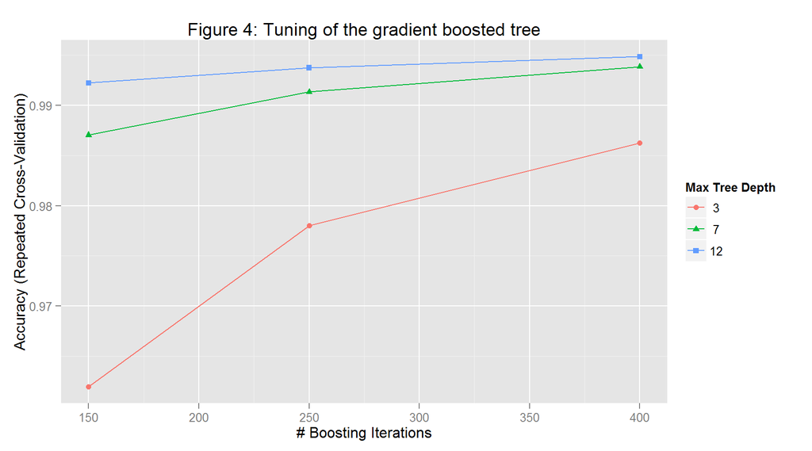

```r
ggplot(booFit) +
       ggtitle("Figure 4: Tuning of the gradient boosted tree")
```

```r
booFit$results[, c(2,4:8)]
```

```
##   interaction.depth n.trees  Accuracy     Kappa  AccuracySD     KappaSD
## 1                 3     150 0.9619530 0.9518676 0.005552630 0.007024512
## 4                 7     150 0.9870430 0.9836101 0.003244464 0.004103507
## 7                12     150 0.9922357 0.9901788 0.002642675 0.003342983
## 2                 3     250 0.9780164 0.9721909 0.004477384 0.005664370
## 5                 7     250 0.9913378 0.9890428 0.002887823 0.003652828
## 8                12     250 0.9937400 0.9920816 0.002321315 0.002936330
## 3                 3     400 0.9862667 0.9826284 0.003942304 0.004987486
## 6                 7     400 0.9938371 0.9922044 0.002258203 0.002856736
## 9                12     400 0.9948561 0.9934934 0.002039462 0.002579894
```

```r
# Fit random forest (use interal estimates of OOB accuracy rather
# than cross-validation as life is short and computers slow)
if (!file.exists("forestFit.RDS")) {
    rfGrid <- expand.grid(mtry= c(2, 7, 26))
    forestFit <- train(classe ~ ., method = "rf", data = pml_mytrain,
                       prox = TRUE, tuneGrid = rfGrid)
    saveRDS(forestFit, file = "forestFit.RDS")
} else {
    forestFit <- readRDS("forestFit.RDS")
}
f_classes <- predict(forestFit)
forestFit$results
```

```
##   mtry  Accuracy     Kappa  AccuracySD     KappaSD
## 1    2 0.9884100 0.9853328 0.001870886 0.002373396
## 2    7 0.9910037 0.9886162 0.001432397 0.001815182
## 3   26 0.9891114 0.9862210 0.001818594 0.002307450
```

```r
# Fit naive Bayes
if (!file.exists("nbFit.RDS")) {
    set.seed(8569)
    tc <- trainControl(method = "repeatedcv", repeats = 3)
    nbFit <- train(classe ~ ., method="nb", data=pml_mytrain,
                   trControl = tc)
    saveRDS(nbFit, file = "nbFit.RDS")
    nb_classes <- predict(nbFit)
    saveRDS(nb_classes, file = "nb_classes.RDS")
} else {
    nbFit <- readRDS("nbFit.RDS")
    nb_classes <- readRDS("nb_classes.RDS")
}
nbFit$results
```

```
##   usekernel fL  Accuracy     Kappa AccuracySD    KappaSD
## 1     FALSE  0 0.5609454 0.4462230 0.01539555 0.01943665
## 2      TRUE  0 0.7470822 0.6820511 0.01257315 0.01571036
```

## Accuracy of the five models

The estimates of the OOB accuracy of the 4 models that were fitted to the same cross-validation samples can be compared directly, but the OOB accuracy of the random forest was estimated using the unselected observations in each bootstrap sample.

The gradient boosted tree and random forest produced much more accurate predictions than the other algorithms. The GBM was significantly more accurate than the other 3 cross-validated models; the Naive Bayes model was significantly more accurate than the other two. The two highly accurate models both produced correct predictions for the entire training set with a predicted OOB accuracy of 99.5%.

Large numbers of the variables contributed materially to the classification process in both the highly accurate models (Figure 5). This finding tend to justify the decision not to use principal components analysis or a singular value decomposition to reduce the 52 variables to a more limited number of features.

```r
# Compare accuracy of the 4 models that were cross-validated
simples <- resamples(list(LDA=ldaFit, Naive_Bayes=nbFit, CART=treeFit,
              Gradient_Boost=booFit))
summary(simples)
```

```
##
## Call:
## summary.resamples(object = simples)
##
## Models: LDA, Naive_Bayes, CART, Gradient_Boost
## Number of resamples: 30
##
## Accuracy
##                  Min. 1st Qu. Median   Mean 3rd Qu.   Max. NA's
## LDA            0.6769  0.6966 0.7059 0.7054  0.7123 0.7247    0
## Naive_Bayes    0.7287  0.7376 0.7456 0.7471  0.7545 0.7706    0
## CART           0.6492  0.6791 0.6925 0.6931  0.7034 0.7424    0
## Gradient_Boost 0.9898  0.9935 0.9949 0.9949  0.9962 0.9985    0
##
## Kappa
##                  Min. 1st Qu. Median   Mean 3rd Qu.   Max. NA's
## LDA            0.5907  0.6161 0.6284 0.6272  0.6355 0.6517    0
## Naive_Bayes    0.6595  0.6699 0.6803 0.6821  0.6915 0.7121    0
## CART           0.5575  0.5951 0.6125 0.6121  0.6250 0.6738    0
## Gradient_Boost 0.9871  0.9917 0.9936 0.9935  0.9952 0.9982    0
```

```r
summary(diff(simples))
```

```
##
## Call:
## summary.diff.resamples(object = diff(simples))
##
## p-value adjustment: bonferroni
## Upper diagonal: estimates of the difference
## Lower diagonal: p-value for H0: difference = 0
##
## Accuracy
##                LDA       Naive_Bayes CART      Gradient_Boost
## LDA                      -0.04166     0.01235  -0.28944
## Naive_Bayes    < 2.2e-16              0.05401  -0.24777
## CART           0.05382   1.876e-12             -0.30179
## Gradient_Boost < 2.2e-16 < 2.2e-16   < 2.2e-16
##
## Kappa
##                LDA       Naive_Bayes CART      Gradient_Boost
## LDA                      -0.05484     0.01508  -0.36628
## Naive_Bayes    < 2.2e-16              0.06992  -0.31144
## CART           0.06191   7.518e-13             -0.38136
## Gradient_Boost < 2.2e-16 < 2.2e-16   < 2.2e-16
```

```r
# Now the performance statistics for the random forest.
forestFit$results[2, ]
```

```
##   mtry  Accuracy     Kappa  AccuracySD     KappaSD
## 2    7 0.9910037 0.9886162 0.001432397 0.001815182
```

```r
forestFit$finalModel
```

```
##
## Call:
##  randomForest(x = x, y = y, mtry = param$mtry, proximity = TRUE)
##                Type of random forest: classification
##                      Number of trees: 500
## No. of variables tried at each split: 7
##
##         OOB estimate of  error rate: 0.46%
## Confusion matrix:
##      A    B    C    D    E class.error
## A 3906    0    0    0    0 0.000000000
## B   11 2643    4    0    0 0.005643341
## C    0   17 2375    4    0 0.008764608
## D    0    0   21 2231    0 0.009325044
## E    0    0    1    5 2519 0.002376238
```

```r
# Confusion matrices for the training data
confusionMatrix(b_classes, pml_mytrain$classe)
```

```
## Confusion Matrix and Statistics
##
##           Reference
## Prediction    A    B    C    D    E
##          A 3906    0    0    0    0
##          B    0 2658    0    0    0
##          C    0    0 2396    0    0
##          D    0    0    0 2252    0
##          E    0    0    0    0 2525
##
## Overall Statistics
##
##                Accuracy : 1
##                  95% CI : (0.9997, 1)
##     No Information Rate : 0.2843
##     P-Value [Acc > NIR] : < 2.2e-16
##
##                   Kappa : 1
##  Mcnemar's Test P-Value : NA
##
## Statistics by Class:
##
##                      Class: A Class: B Class: C Class: D Class: E
## Sensitivity            1.0000   1.0000   1.0000   1.0000   1.0000
## Specificity            1.0000   1.0000   1.0000   1.0000   1.0000
## Pos Pred Value         1.0000   1.0000   1.0000   1.0000   1.0000
## Neg Pred Value         1.0000   1.0000   1.0000   1.0000   1.0000
## Prevalence             0.2843   0.1935   0.1744   0.1639   0.1838
## Detection Rate         0.2843   0.1935   0.1744   0.1639   0.1838
## Detection Prevalence   0.2843   0.1935   0.1744   0.1639   0.1838
## Balanced Accuracy      1.0000   1.0000   1.0000   1.0000   1.0000
```

```r
confusionMatrix(f_classes, pml_mytrain$classe)
```

```
## Confusion Matrix and Statistics
##
##           Reference
## Prediction    A    B    C    D    E
##          A 3906    0    0    0    0
##          B    0 2658    0    0    0
##          C    0    0 2396    0    0
##          D    0    0    0 2252    0
##          E    0    0    0    0 2525
##
## Overall Statistics
##
##                Accuracy : 1
##                  95% CI : (0.9997, 1)
##     No Information Rate : 0.2843
##     P-Value [Acc > NIR] : < 2.2e-16
##
##                   Kappa : 1
##  Mcnemar's Test P-Value : NA
##
## Statistics by Class:
##
##                      Class: A Class: B Class: C Class: D Class: E
## Sensitivity            1.0000   1.0000   1.0000   1.0000   1.0000
## Specificity            1.0000   1.0000   1.0000   1.0000   1.0000
## Pos Pred Value         1.0000   1.0000   1.0000   1.0000   1.0000
## Neg Pred Value         1.0000   1.0000   1.0000   1.0000   1.0000
## Prevalence             0.2843   0.1935   0.1744   0.1639   0.1838
## Detection Rate         0.2843   0.1935   0.1744   0.1639   0.1838
## Detection Prevalence   0.2843   0.1935   0.1744   0.1639   0.1838
## Balanced Accuracy      1.0000   1.0000   1.0000   1.0000   1.0000
```

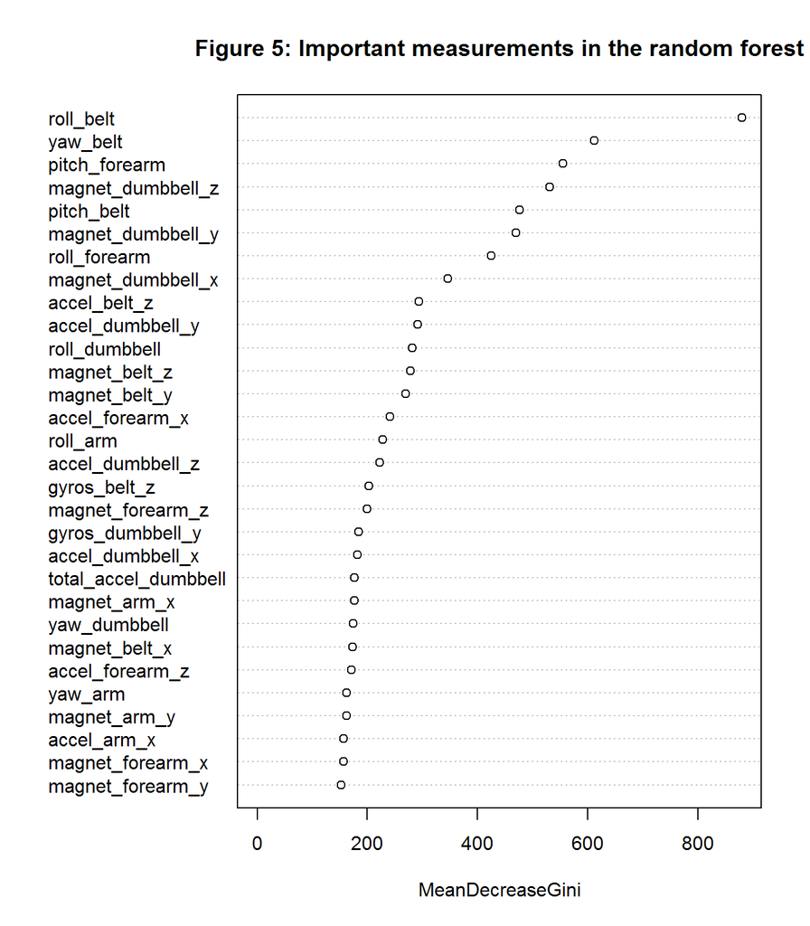

```r
# Variable importance plot for the random forest
varImpPlot(forestFit$finalModel,
    main = "Figure 5: Important measurements in the random forest")
```

## Estimated out-of-bag errors based on the test data

To check the out-of-bag accuracy of the predictions produced by the two most promising models, each was applied to the test data. Both models performed very slightly worse on this particular sample of test data than had been predicted using the training data. The gradient boosted model was slightly more accurate than the random forest (99.35% versus 99.27%), getting 5 more of the 5885 predictions in the test data correct.

```r
# Boosted tree
pml_mytest <-readRDS("pml_mytest.RDS")
btest_classes <- predict(booFit, pml_mytest)
confusionMatrix(btest_classes, pml_mytest$classe)
```

```
## Confusion Matrix and Statistics
##
##           Reference
## Prediction    A    B    C    D    E
##          A 1671    8    0    0    0
##          B    1 1126    2    0    2
##          C    2    5 1017    3    0
##          D    0    0    7  958    5
##          E    0    0    0    3 1075
##
## Overall Statistics
##
##                Accuracy : 0.9935
##                  95% CI : (0.9911, 0.9954)
##     No Information Rate : 0.2845
##     P-Value [Acc > NIR] : < 2.2e-16
##
##                   Kappa : 0.9918
##  Mcnemar's Test P-Value : NA
##
## Statistics by Class:
##
##                      Class: A Class: B Class: C Class: D Class: E
## Sensitivity            0.9982   0.9886   0.9912   0.9938   0.9935
## Specificity            0.9981   0.9989   0.9979   0.9976   0.9994
## Pos Pred Value         0.9952   0.9956   0.9903   0.9876   0.9972
## Neg Pred Value         0.9993   0.9973   0.9981   0.9988   0.9985
## Prevalence             0.2845   0.1935   0.1743   0.1638   0.1839
## Detection Rate         0.2839   0.1913   0.1728   0.1628   0.1827
## Detection Prevalence   0.2853   0.1922   0.1745   0.1648   0.1832
## Balanced Accuracy      0.9982   0.9938   0.9946   0.9957   0.9965
```

```r
# Random forest
ftest_classes <- predict(forestFit, pml_mytest)
confusionMatrix(ftest_classes,pml_mytest$classe)
```

```
## Confusion Matrix and Statistics
##
##           Reference
## Prediction    A    B    C    D    E
##          A 1673   10    0    0    0
##          B    1 1125    6    0    0
##          C    0    4 1018    7    0
##          D    0    0    2  952    8
##          E    0    0    0    5 1074
##
## Overall Statistics
##
##                Accuracy : 0.9927
##                  95% CI : (0.9902, 0.9947)
##     No Information Rate : 0.2845
##     P-Value [Acc > NIR] : < 2.2e-16
##
##                   Kappa : 0.9908
##  Mcnemar's Test P-Value : NA
##
## Statistics by Class:
##
##                      Class: A Class: B Class: C Class: D Class: E
## Sensitivity            0.9994   0.9877   0.9922   0.9876   0.9926
## Specificity            0.9976   0.9985   0.9977   0.9980   0.9990
## Pos Pred Value         0.9941   0.9938   0.9893   0.9896   0.9954
## Neg Pred Value         0.9998   0.9971   0.9984   0.9976   0.9983
## Prevalence             0.2845   0.1935   0.1743   0.1638   0.1839
## Detection Rate         0.2843   0.1912   0.1730   0.1618   0.1825
## Detection Prevalence   0.2860   0.1924   0.1749   0.1635   0.1833
## Balanced Accuracy      0.9985   0.9931   0.9950   0.9928   0.9958
```

```r
# Cross-check the GBM against the random forest
boost_OK <- btest_classes==pml_mytest$classe
forest_OK <- ftest_classes==pml_mytest$classe
table(boost_OK,forest_OK)
```

```
##         forest_OK
## boost_OK FALSE TRUE
##    FALSE    24   14
##    TRUE     19 5828
```

## Predictions for the 20 unclassified cases

Finally, the two highly accurate models were used to classify the 20 measurements for which the category of the dumb bell lift had been held back. The two models made identical predictions.

```r
if (!exists("pml_final")) pml_final <- readRDS("pml_final.RDS")
fftest_classes <- predict(forestFit, pml_final)
bftest_classes <- predict(booFit, pml_final)
identical(bftest_classes, fftest_classes)
```

```
## [1] TRUE
```

## References

Velloso, E.; Bulling, A.; Gellersen, H.; Ugulino, W.; Fuks, H. [Qualitative Activity Recognition of Weight Lifting Exercises](http://groupware.les.inf.puc-rio.br/public/papers/2013.Velloso.QAR-WLE.pdf). Proceedings of 4th International Augmented Human Conference, Stuttgart, Germany. ACM SIGCHI, 2013.

### Software environment

```r
Sys.info()[1:2]; Sys.info()[3]; R.version.string
```

```
##   sysname   release
## "Windows"   "7 x64"
```

```
##                      version
## "build 7601, Service Pack 1"
```

```
## [1] "R version 3.2.1 (2015-06-18)"
```